# DATA 550 Lab 2 - EDA on movie data

There are two versions of this lab, one in Python and one in R. The R lab will use `ggplot` and the Python lab will use `Altair`.

**This is the R version.**

Each partner should choose a version to complete, though keep in mind that **you are required to alternate between completing the R labs and the Python labs** to get experience using both languages.

## Acknowledgemnts

This lab was lightly adapted from the one created by Joel Ostblom for the DSCI 531 version of Data Viz I in the 2020/21 Academic year.

## Submission instructions

rubric={mechanics:2}

You receive marks for submitting your lab correctly, please follow these instructions:

- Each partner should complete one file, though collaboration is permitted.
- Push your `.ipynb` files to GitHub frequently (i.e. not just in one fell swoop at the end).
- Don't forget to submit a clickable link to your GitHub repo on Canvas so we can grade it.

# 0. Get motivated!

I have heard that the movie market is a lucrative business, and have been looking into starting my own online streaming service together with a few friends. Before we do this, we need to understand the movie market better so that we can get a competitive edge over existing service. I have been looking all over for an aspiring data wrangler and future VIZARD, but haven't been able to track one down. This is where you come in!

[figure not shown]

Together, we must understand the current movie market, which companies produces what kind of movies, and which receive good scores. Then we can have the best movies on our platform and show only those, easy right? I mean...we will show only good movies, I can't believe no one has thought of this before! I have already identified a unique name for this service: Bestflix™.

Don't worry, we're in this together and I will be helping you with the wrangling throughout most exercises if you take charge of the viz part, deal?. Also, I have never failed to start a company before, so you're in good hands. I can already smell the `$$$`, so let's get started!

In this notebook, we will focus on Exploratory Data Analysis (EDA), both for single numerical columns, pairwise numerical columns, numerical columns conditioned on categorical columns and combinations of categorical columns.

# 1. Single numerical columns

### Question 1.1

rubric={reasoning:1,accuracy:1}

#### R

In the beginning of EDA, it can be good to look at some textual summaries, just to get an idea of what to plot. The data file is caled `lab2-movies.json`. Read it in using the sample code below, then do the following in three different cells:

1. Display the first few rows of the data.
2. Display info about all columns, including their data types.
3. Display a summary description of the data frame's numerical columns only.

```r
library(rjson)
library(tidyverse)
movies <- fromJSON(file = 'data/lab2-movies.json') %>%
    as_tibble() %>%
    unnest(-c(studios, genres))
```

```r
glimpse(movies)
```

```
Rows: 1,008
Columns: 9
$ id           <dbl> 12, 13, 14, 16, 22, 58, 59, 70, 73, 74, 76, 78, 85, 87, 8…
$ title        <chr> "Finding Nemo", "Forrest Gump", "American Beauty", "Dance…
$ runtime      <dbl> 100, 142, 122, 140, 143, 151, 96, 132, 119, 116, 105, 117…
$ budget       <dbl> 9.40e+07, 5.50e+07, 1.50e+07, 1.28e+07, 1.40e+08, 2.00e+0…
$ revenue      <dbl> 940335536, 677945399, 356296601, 40031879, 655011224, 106…
$ vote_average <dbl> 3.86, 4.05, 4.13, 3.84, 3.81, 3.47, 3.63, 3.84, 4.15, 3.1…
$ vote_count   <dbl> 33887, 91921, 57879, 4571, 36337, 15079, 5082, 13901, 318…
$ genres       <named list> "Animation", <"Romance", "Comedy", "Drama">, "Dram…
$ studios      <named list> "Pixar Animation Studios", "Paramount Pictures", "…
```

```r
movies %>%
  select(where(is.numeric)) %>%
  summary()
```

```
       id            runtime          budget            revenue
 Min.   :    12   Min.   : 63.0   Min.   :5.00e+00   Min.   :8.500e+01
 1st Qu.:  3627   1st Qu.: 96.0   1st Qu.:2.00e+07   1st Qu.:4.128e+07
 Median : 10432   Median :108.0   Median :4.00e+07   Median :1.019e+08
 Mean   : 49889   Mean   :112.2   Mean   :5.94e+07   Mean   :1.879e+08
 3rd Qu.: 44659   3rd Qu.:125.0   3rd Qu.:8.00e+07   3rd Qu.:2.271e+08
 Max.   :417644   Max.   :202.0   Max.   :3.80e+08   Max.   :2.788e+09
  vote_average     vote_count
 Min.   :1.610   Min.   :   11
 1st Qu.:2.947   1st Qu.:  857
 Median :3.265   Median : 2688
 Mean   :3.240   Mean   : 6907
 3rd Qu.:3.590   3rd Qu.: 8774
 Max.   :4.430   Max.   :91921
```

### Question 1.2

rubric={viz:1,accuracy:1,reasoning:1}

#### R

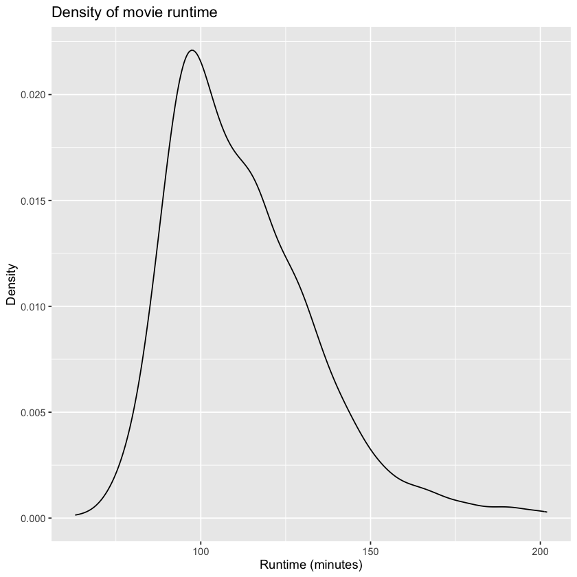

```r
ggplot(movies, aes(x = runtime)) +
  geom_density() +
  labs(
    x = "Runtime (minutes)",
    y = "Density",
    title = "Density of movie runtime"
  )
```

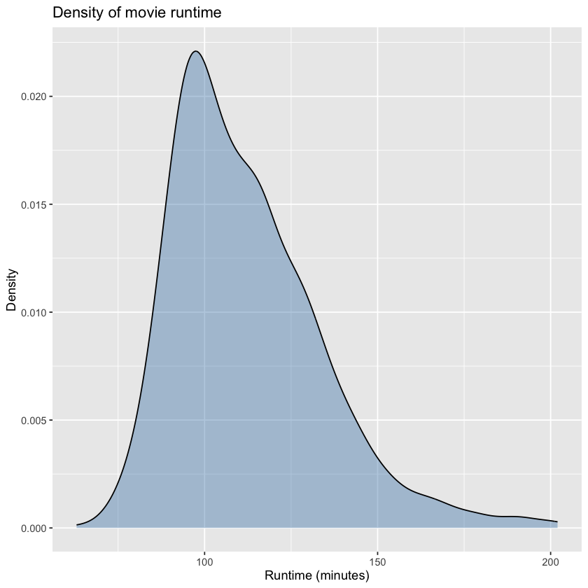

```r
ggplot(movies, aes(x = runtime)) +
  geom_density(alpha = 0.4, fill = "steelblue") +
  labs(
    x = "Runtime (minutes)",
    y = "Density",
    title = "Density of movie runtime"
  )
```

### Question 1.3

rubric={viz:2,accuracy:2}

#### R

- Pipe the data fame's numerical columns (except `id`) into ggplot (the `.select_if()` method can help here, or you can do it manually).
- Copy the code from your density plot above and paste it here. Modify the code so that it accepts the piped dataframe and plots one density estimate per column in a plot grid with 2 columns and 3 rows. Don’t use a loop, use pivoting and faceting instead (example in the lecture videos).

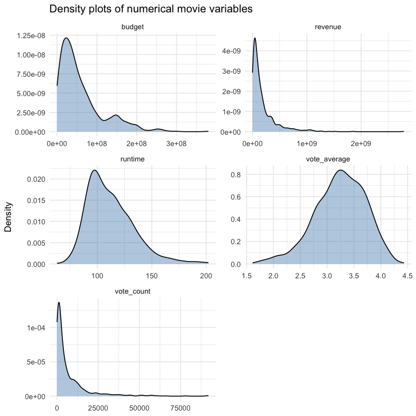

```r
movies %>%
  select(where(is.numeric), -id) %>%
  pivot_longer(everything(), names_to = "variable", values_to = "value") %>%
  ggplot(aes(x = value)) +
  geom_density(alpha = 0.4, fill = "steelblue") +
  facet_wrap(~ variable, ncol = 2, scales = "free") +
  labs(x = NULL, y = "Density",
       title = "Density plots of numerical movie variables") +
  theme_minimal()
```

# 2. Pairwise numerical columns

### Question 2.1

rubric={viz:1,accuracy:1}

#### R

Next, let’s look at the relationships between pairs of numerical columns.For this we will create a scatterplot matrix (SPLOM) for all numerical columns except `id`.

There is nothing built into `ggplot` for this but the `GGally` package has a handy `ggpairs` function for this, which also plots single column densities on the diagonal and correlation coefficients on the upper corner. Install this package an then use the `ggpairs`.

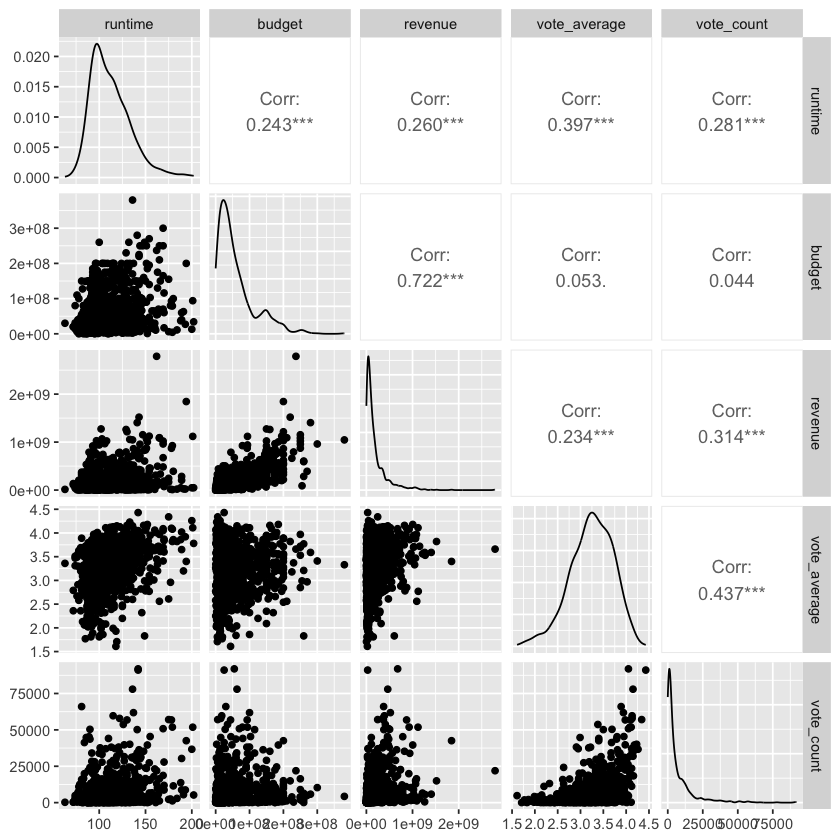

```r
library(GGally)
library(tidyverse)
movies %>%
  select(where(is.numeric), -id) %>%
  ggpairs()
```

### Question 2.2 (Optional)

rubric={accuracy:0.5,reasoning:0.5}

#### R

We're getting close, dont give up! Remember, we're in it for the `$$$`

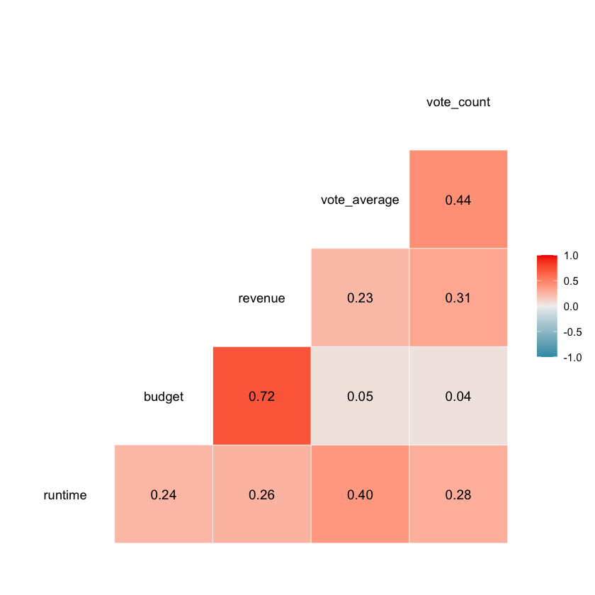

```r
library(GGally)
library(tidyverse)

movies %>%
  select(where(is.numeric), -id) %>%
  ggcorr(label = TRUE, label_round = 2)
```

# 3. EDA of numerical columns conditioned on a categorical column (genres)

### Question 3.1

rubric={viz:1,accuracy:2}

#### R

Let's create a explosion in R. In the tidyverse, exploding a list / vector from a column is referred to as unnesting it, less action-packed but maybe even more descriptive? =)

I have already done the necessary wrangling here, but please view the df so that you understand what happened and [check out tidyr doc for a simpler example](https://tidyr.tidyverse.org/reference/nest.html).

1. Use this new dataframe and create multiple violinplots inside a single figure by having genres on the y-axis and revenue on the x axis.
2. Read the documentation of the violin plot to find out how you can use its parameters to add a line for the median (hint: the same as quantile 0.5).
3. As we did in the previous lecture with `add_count()`, we need to create a new column for sorting, this time using `mutate()`. I want you to sort the genres by median revenue, so that the median lines of the violin plots are nicely sorted. I have given you a skeleton below where you can fill in the blanks, but you are also free to do it your own way. Then use the same function as previous lectures to sort by this new column.

```r
library(tidyverse)
free_genres <- movies %>%
  unnest(genres)
```

```r
free_genres <- free_genres %>%
  group_by(genres) %>%
  mutate(median_revenue = median(revenue, na.rm = TRUE)) %>%
  ungroup()
```

```r
free_genres <- free_genres %>%
  mutate(genres = fct_reorder(genres, median_revenue))
```

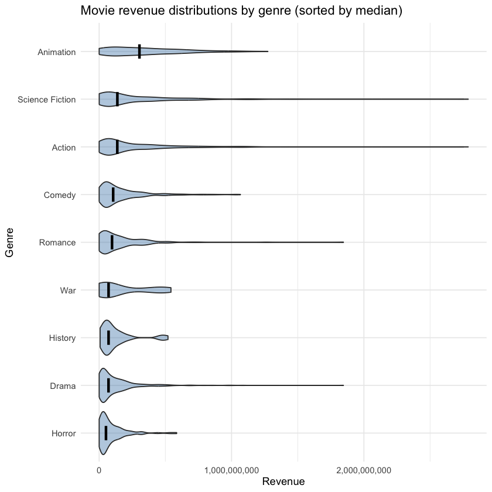

```r
ggplot(free_genres, aes(x = revenue, y = genres)) +
  geom_violin(fill = "steelblue", alpha = 0.4) +
  stat_summary(
    fun = median,
    geom = "crossbar",
    width = 0.3,
    color = "black"
  ) +
  scale_x_continuous(labels = scales::comma) +
  labs(
    x = "Revenue",
    y = "Genre",
    title = "Movie revenue distributions by genre (sorted by median)"
  ) +
  theme_minimal()
```

### Question 3.2

rubric={viz:1,accuracy:2}

Don't give up soldier, you're almost done with this lab! Bestflix future rests with you.

#### R

1. Copy the code from your violinplot above and use the same faceting strategy as for the histograms to repeat this violinplot for all numerical values (you don't need to sort the y-axis by different columns, it is better that categories are sorted by median revenue in all facets so that we don't have to keep track of how they move around between subplots).
   - In contrast to the histograms you will here need to save the genres and medium_income columns by using the `!` syntax in your call to `pivot_longer`, see the [example in the manual for how to do this](https://tidyr.tidyverse.org/reference/pivot_longer.html).
   - You will also need to define both x and y in your `aes()`, just like in the single violinplot you made above.

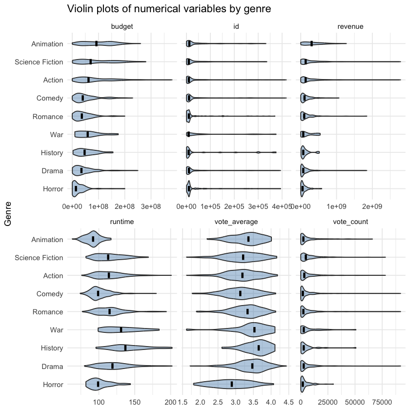

```r
free_genres %>%
  pivot_longer(
    cols = where(is.numeric) & !median_revenue,
    names_to = "variable",
    values_to = "value"
  ) %>%
  ggplot(aes(x = value, y = genres)) +
  geom_violin(fill = "steelblue", alpha = 0.4) +
  stat_summary(
    fun = median,
    geom = "crossbar",
    width = 0.3,
    color = "black"
  ) +
  facet_wrap(~ variable, scales = "free_x") +
  labs(
    x = NULL,
    y = "Genre",
    title = "Violin plots of numerical variables by genre"
  ) +
  theme_minimal()
```

### Question 3.3 (Optional)

rubric={accuracy:0.5,reasoning:0.5}

#### R

1. Copy over the code from the faceted violinplots above.
2. In contrast to boxplots, violinplots can show an indication of counts by scaling their area based on the number of observations instead of keeping it the same in all violins. Read the violin plot documentation and find the variable that controls the scaling of the area and change it so that the violins indicate the count of the observations.
3. Compare this to the approach we used in Altair for a boxplot + a barplot for counts, which approach do you think is clearer for getting a feeling for the number of observation in each group and why?

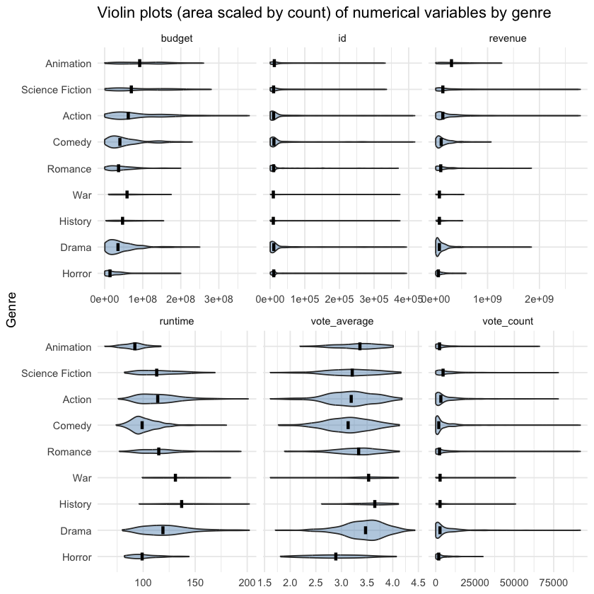

```r
library(tidyverse)

free_genres <- movies %>%
  unnest(genres) %>%
  group_by(genres) %>%
  mutate(median_revenue = median(revenue, na.rm = TRUE)) %>%
  ungroup() %>%
  mutate(genres = fct_reorder(genres, median_revenue))

free_genres %>%
  pivot_longer(
    cols = where(is.numeric) & !median_revenue,
    names_to = "variable",
    values_to = "value"
  ) %>%
  ggplot(aes(x = value, y = genres)) +
  geom_violin(scale = "count", fill = "steelblue", alpha = 0.4) +  # <- 這行是重點
  stat_summary(fun = median, geom = "crossbar", width = 0.3, color = "black") +
  facet_wrap(~ variable, scales = "free_x") +
  labs(
    x = NULL,
    y = "Genre",
    title = "Violin plots (area scaled by count) of numerical variables by genre"
  ) +
  theme_minimal()
```

### Question 3.4 (Optional)

rubric={accuracy:0.5,reasoning:0.5}

#### R

Let’s see how the numerical columns vary with different production studios.

1. Create a new dataframe from exploding/unnesting the `studios` column in the `movies` dataframe. You can use my code from above to guide you.
2. Create a similar sorting list as before, but this time with the studies sorted by median revenue.
3. Create the same repeated boxplots for the studios. A tip when you are creating similar plots for two different sections of your notebook, is to use a different color for each so that it is easy to orient yourself (unless you are encoding color as a visual aesthetic of course, but we’re not doing that here). Pick any HTML color either via its hex code or by choosing a name from [this list of named colors](https://stackoverflow.com/a/37232759/2166823). Color all the bars and boxes in this color by setting it inside `mark_boxplot()` / `geom_boxplot()`.
4. Create the same barplot of counts as above for the studios. Color the bars in the same colors as the boxplots.
5. Reflect on the information in the boxplot and / or the barplot. Identify two interesting relationships / questions / discoveries that stand out to you and that you would want to explore further. Briefly motivate why (<90 words).

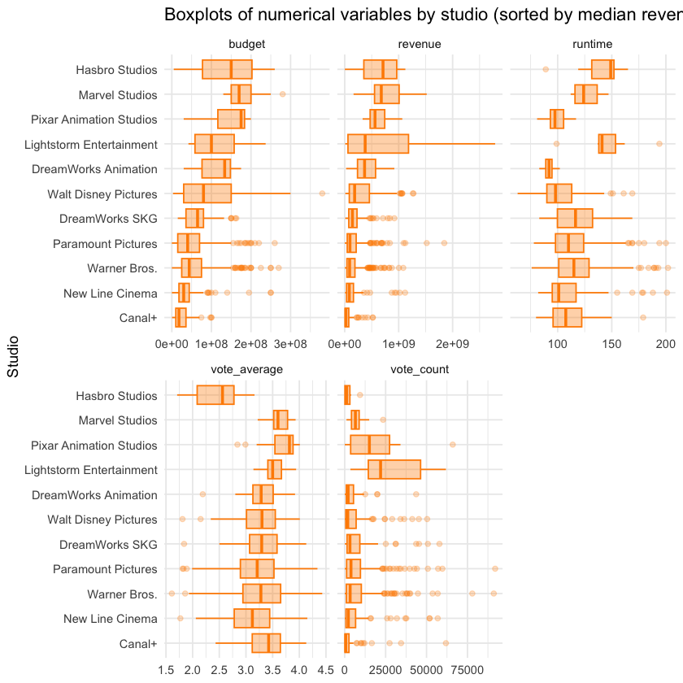

```r
library(tidyverse)

free_studios <- movies %>%
  unnest(studios) %>%
  group_by(studios) %>%
  mutate(median_revenue = median(revenue, na.rm = TRUE)) %>%
  ungroup() %>%
  mutate(studios = fct_reorder(studios, median_revenue))

free_studios %>%
  pivot_longer(
    cols = where(is.numeric) & !median_revenue & !id,   # 排除 id 與 median_revenue
    names_to = "variable",
    values_to = "value"
  ) %>%
  ggplot(aes(x = value, y = studios)) +
  geom_boxplot(color = "darkorange", fill = "darkorange", alpha = 0.35, outlier.alpha = 0.25) +
  facet_wrap(~ variable, scales = "free_x") +
  labs(
    x = NULL,
    y = "Studio",
    title = "Boxplots of numerical variables by studio (sorted by median revenue)"
  ) +
  theme_minimal()
```

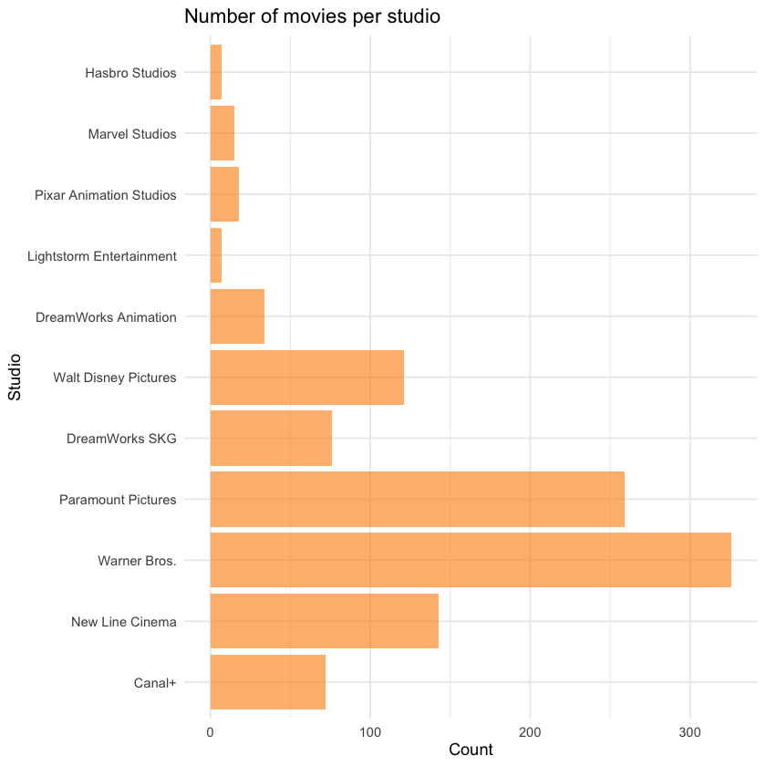

```r
free_studios %>%
  count(studios, sort = TRUE) %>%
  ggplot(aes(x = n, y = studios)) +
  geom_col(fill = "darkorange", alpha = 0.6) +
  labs(
    x = "Count",
    y = "Studio",
    title = "Number of movies per studio"
  ) +
  theme_minimal()
```

Two patterns stand out. First, some studios have a high median revenue but relatively few movies, suggesting they focus on fewer “blockbusters” rather than volume; I’d like to check whether this persists after adjusting for budget. Second, studios with many movies often show wide variability (long upper tails) in revenue and budget, raising the question of whether portfolio diversity or franchise strategy drives the spread. These are worth exploring with log scales and per-year trends.

# 4. EDA of categorical columns

### Question 4.1

rubric={viz:1,accuracy:1}

1. Go through the [GGally example plots](http://ggobi.github.io/ggally/articles/ggally_plots.html) and find a plot that you think is suitable for showing the count of the combination of categorical variables. Use this plot to visualize the counts.
2. Create another plot of the counts by first using `add_count()` to add a count for all the combinations of genres and studios. This column will be called `n` and you can map it to an appropriate aesthetics encoding and visualize the results with `geom_tile` to create a heatmap of counts.

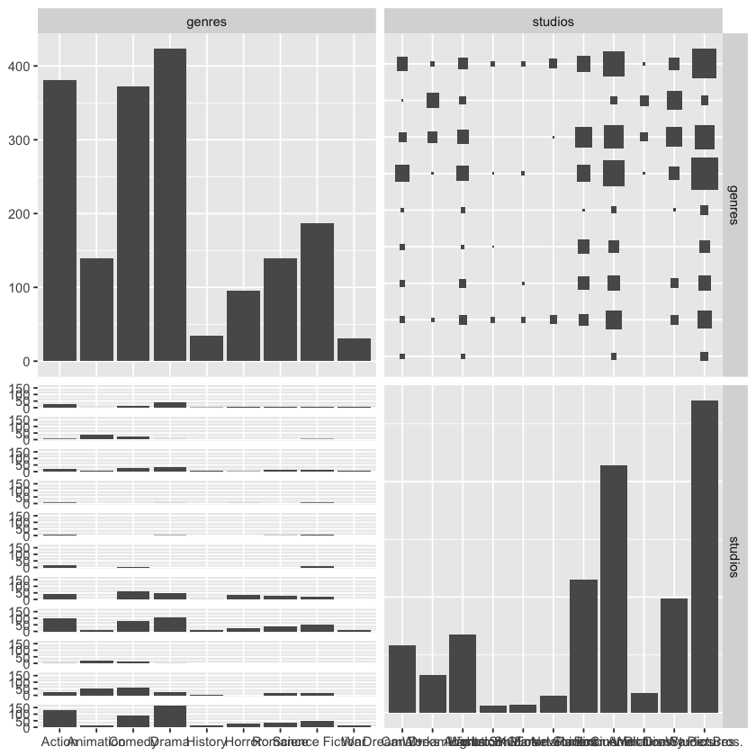

```r
library(tidyverse)
library(GGally)

cat_df <- movies %>%
  unnest(genres) %>%
  unnest(studios) %>%
  select(genres, studios)

GGally::ggpairs(cat_df)
```

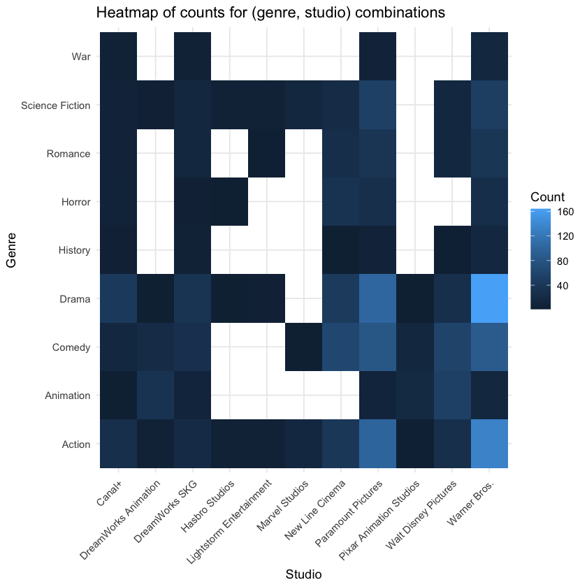

```r
movies %>%
  unnest(genres) %>%
  unnest(studios) %>%
  add_count(genres, studios, name = "n") %>%
  distinct(genres, studios, n) %>%
  ggplot(aes(x = studios, y = genres, fill = n)) +
  geom_tile() +
  labs(
    x = "Studio",
    y = "Genre",
    fill = "Count",
    title = "Heatmap of counts for (genre, studio) combinations"
  ) +
  theme_minimal() +
  theme(axis.text.x = element_text(angle = 45, hjust = 1))
```

### Question 4.2 (Optional)

rubric={accuracy:1}

#### R

The plots above are great for comparing absolute counts, but that means that studios with smaller production volume gets drowned out. Let's instead visualize the proportion within each studio for each genre. Calculate the proportion for each studio - genre pair, so that for each studio, the genre proportions adds up to 1. Visualize with your favorite categorical count plot.

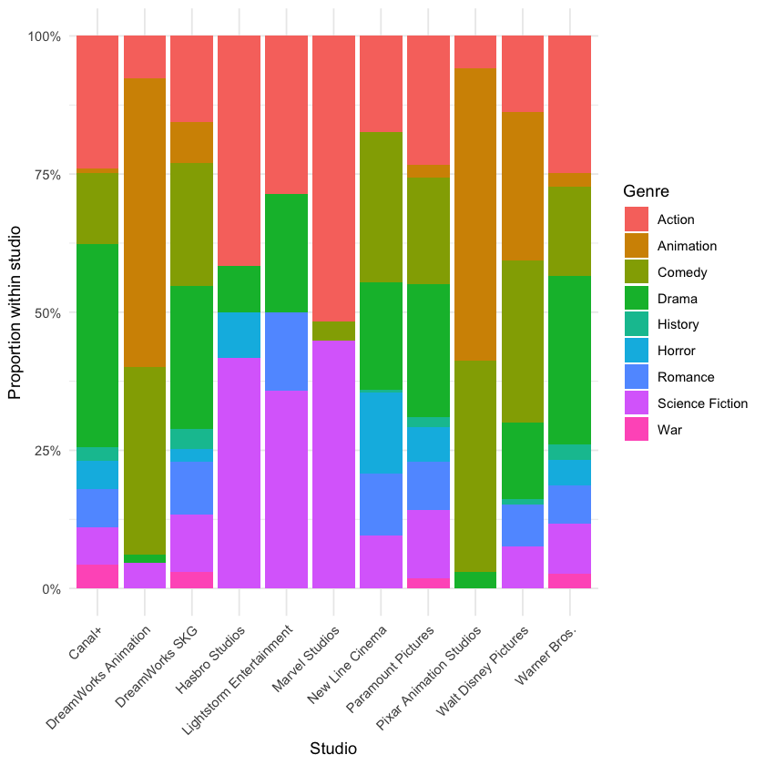

```r
movies %>%
  unnest(genres) %>%
  unnest(studios) %>%
  ggplot(aes(x = studios, fill = genres)) +
  geom_bar(position = "fill") +
  scale_y_continuous(labels = scales::percent) +
  labs(x = "Studio", y = "Proportion within studio", fill = "Genre") +
  theme_minimal() +
  theme(axis.text.x = element_text(angle = 45, hjust = 1))
```

# Submission to Canvas

When you are ready to submit your assignment do the following:

1. Run all cells in your notebook to make sure there are no errors by doing `Kernel -> Restart Kernel and Run All Cells...`
2. Commit and push all your work (including the .ipynb file) to GitHub.
3. Submit a link to your repo on Canvas (this has to be done only once per group).